# Graphical parameters of {graphics} package

## srt

The string rotation in degrees. See the comment about crt. Only supported by text.

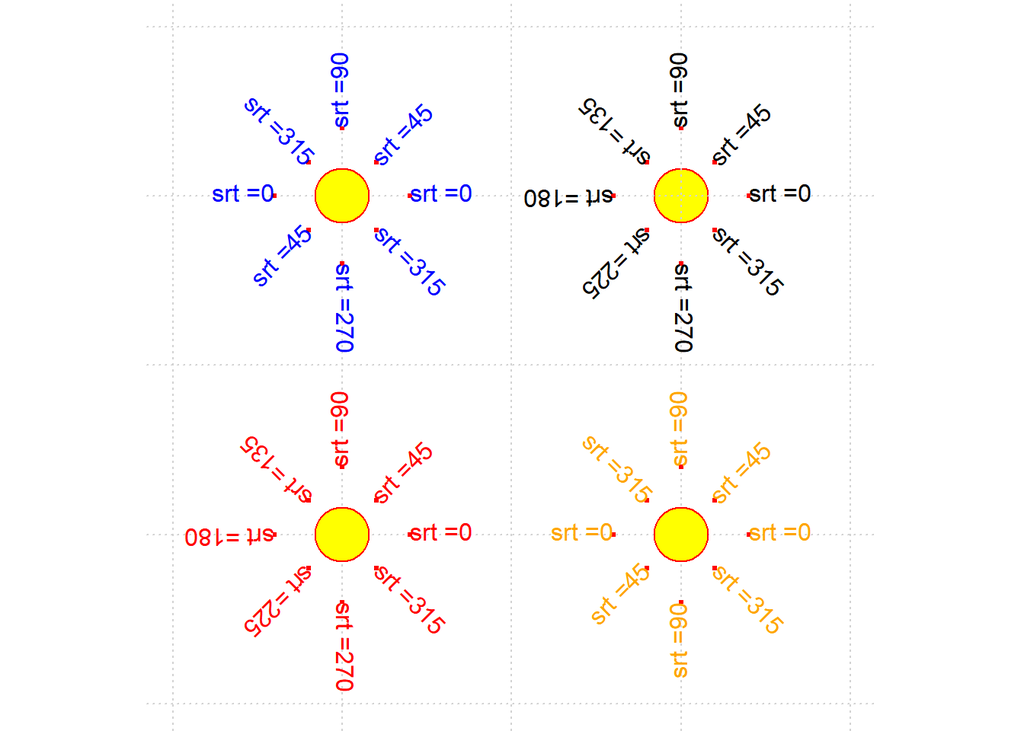

```r
old_par <- par(pty = 's', mai = rep(0, 4))


#  star 1
col_text <- "black"
x <- 5; y <- 5
plot(0 + x, 0 + y
    , xlim = c(-10, 10), ylim = c(-10, 10)
    , axes = FALSE
    , xlab = "", ylab = ""
    , pch = 21, col = "red", bg = "yellow", cex = 5)
grid()
points(c(0, 0, 2, -2, 1, -1, -1, 1) + x, c(2, -2, 0, 0, 1, 1, -1, -1) + y
    , pch = ".", col = "red", cex = 3)
text(2 + x, 0 + y, paste("srt", "=0"), srt = 0, adj = c(0, 0.3), col = col_text[1])
text(1 + x, 1 + y, paste("srt", "=45"), srt = 45, adj = c(0, 0.3), col = col_text[2])
text(0 + x, 2 + y, paste("srt", "=90"), srt = 90, adj = c(0, 0.3), col = col_text[3])
text(-1 + x, 1 + y, paste("srt", "=135"), srt = 135, adj = c(0, 0.3), col = col_text[4])
text(-2 + x, 0 + y, paste("srt", "=180"), srt = 180, adj = c(0, 0.3), col = col_text[5])
text(-1 + x, -1 + y, paste("srt", "=225"), srt = 225, adj = c(0, 0.3), col = col_text[6])
text(0 + x, -2 + y, paste("srt", "=270"), srt = 270, adj = c(0, 0.3), col = col_text[7])
text(1 + x, -1 + y, paste("srt", "=315"), srt = 315, adj = c(0, 0.3), col = col_text[8])

# star 2
par(new = TRUE)
col_text <- rep("red", 8)
x <- -5; y <- -5
plot(0 + x, 0 + y
    , xlim = c(-10, 10), ylim = c(-10, 10)
    , axes = FALSE
    , xlab = "", ylab = ""
    , pch = 21, col = "red", bg = "yellow", cex = 5)

points(c(0, 0, 2, -2, 1, -1, -1, 1) + x, c(2, -2, 0, 0, 1, 1, -1, -1) + y
    , pch = ".", col = "red", cex = 3)
text(2 + x, 0 + y, paste("srt", "=0"), srt = 0, adj = c(0, 0.3), col = col_text[1])
text(1 + x, 1 + y, paste("srt", "=45"), srt = 45, adj = c(0, 0.3), col = col_text[2])
text(0 + x, 2 + y, paste("srt", "=90"), srt = 90, adj = c(0, 0.3), col = col_text[3])
text(-1 + x, 1 + y, paste("srt", "=135"), srt = 135, adj = c(0, 0.3), col = col_text[4])
text(-2 + x, 0 + y, paste("srt", "=180"), srt = 180, adj = c(0, 0.3), col = col_text[5])
text(-1 + x, -1 + y, paste("srt", "=225"), srt = 225, adj = c(0, 0.3), col = col_text[6])
text(0 + x, -2 + y, paste("srt", "=270"), srt = 270, adj = c(0, 0.3), col = col_text[7])
text(1 + x, -1 + y, paste("srt", "=315"), srt = 315, adj = c(0, 0.3), col = col_text[8])

# star 3
par(new = TRUE)
col_text <- rep("blue", 8)
x <- -5; y <- 5
plot(0 + x, 0 + y
    , xlim = c(-10, 10), ylim = c(-10, 10)
    , axes = FALSE
    , xlab = "", ylab = ""
    , pch = 21, col = "red", bg = "yellow", cex = 5)

points(c(0, 0, 2, -2, 1, -1, -1, 1) + x, c(2, -2, 0, 0, 1, 1, -1, -1) + y
    , pch = ".", col = "red", cex = 3)
text(2 + x, 0 + y, paste("srt", "=0"), srt = 0, adj = c(0, 0.3), col = col_text[1])
text(1 + x, 1 + y, paste("srt", "=45"), srt = 45, adj = c(0, 0.3), col = col_text[2])
text(0 + x, 2 + y, paste("srt", "=90"), srt = 90, adj = c(0, 0.3), col = col_text[3])
text(-1 + x, 1 + y, paste("srt", "=315"), srt = 315, adj = c(1, 0.3), col = col_text[4])
text(-2 + x, 0 + y, paste("srt", "=0"), srt = 0, adj = c(1, 0.3), col = col_text[5])
text(-1 + x, -1 + y, paste("srt", "=45"), srt = 45, adj = c(1, 0.3), col = col_text[6])
text(0 + x, -2 + y, paste("srt", "=270"), srt = 270, adj = c(0, 0.3), col = col_text[7])
text(1 + x, -1 + y, paste("srt", "=315"), srt = 315, adj = c(0, 0.3), col = col_text[8])

# star 4
par(new = TRUE)
col_text <- rep("orange", 8)
x <- 5; y <- -5
plot(0 + x, 0 + y
    , xlim = c(-10, 10), ylim = c(-10, 10)
    , axes = FALSE
    , xlab = "", ylab = ""
    , pch = 21, col = "red", bg = "yellow", cex = 5)

points(c(0, 0, 2, -2, 1, -1, -1, 1) + x, c(2, -2, 0, 0, 1, 1, -1, -1) + y
    , pch = ".", col = "red", cex = 3)
text(2 + x, 0 + y, paste("srt", "=0"), srt = 0, adj = c(0, 0.3), col = col_text[1])
text(1 + x, 1 + y, paste("srt", "=45"), srt = 45, adj = c(0, 0.3), col = col_text[2])
text(0 + x, 2 + y, paste("srt", "=90"), srt = 90, adj = c(0, 0.3), col = col_text[3])
text(-1 + x, 1 + y, paste("srt", "=315"), srt = 315, adj = c(1, 0.3), col = col_text[4])
text(-2 + x, 0 + y, paste("srt", "=0"), srt = 0, adj = c(1, 0.3), col = col_text[5])
text(-1 + x, -1 + y, paste("srt", "=45"), srt = 45, adj = c(1, 0.3), col = col_text[6])
text(0 + x, -2 + y, paste("srt", "=90"), srt = 90, adj = c(1, 0.3), col = col_text[7])
text(1 + x, -1 + y, paste("srt", "=315"), srt = 315, adj = c(0, 0.3), col = col_text[8])
```

```r
par(old_par)
```

## tck

The length of tick marks as a fraction of the smaller of the width or height of the plotting region. If tck >= 0.5 it is interpreted as a fraction of the relevant side, so if tck = 1 grid lines are drawn. The default setting (tck = NA) is to use tcl = -0.5.

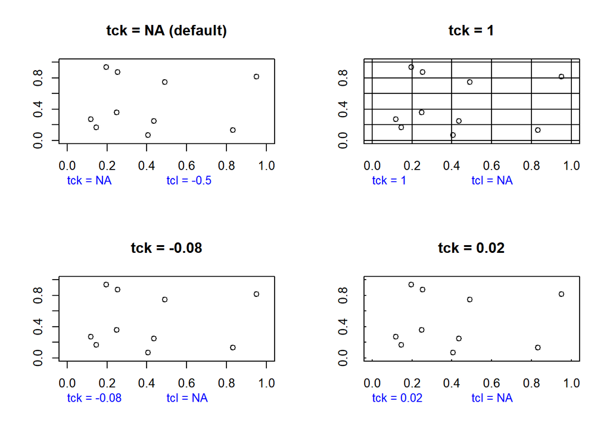

```r
opnew <- par(mfrow = c(2,2), tck = NA)
set.seed(1023)
plot(runif(10), runif(10)
    ,xlim = c(0, 1), ylim = c(0, 1)
    ,xlab = "", ylab = ""
    ,main = "tck = NA (default)")
mtext(side = 1, line = 2, at = 0
    , paste0("tck = ", round(par("tck"), 2))
    , cex = 0.8, col = "blue", adj = 0)
mtext(side = 1, line = 2, at = 0.5
    , paste0("tcl = ", round(par("tcl"), 2))
    , cex = 0.8, col = "blue", adj = 0)

par(tck = 1)
set.seed(1023)
plot(runif(10), runif(10)
    ,xlim = c(0, 1), ylim = c(0, 1)
    ,xlab = "", ylab = ""
    ,main = "tck = 1")
mtext(side = 1, line = 2, at = 0
    , paste0("tck = ", round(par("tck"), 2))
    , cex = 0.8, col = "blue", adj = 0)
mtext(side = 1, line = 2, at = 0.5
    , paste0("tcl = ", round(par("tcl"), 2))
    , cex = 0.8, col = "blue", adj = 0)

par(tck = -0.08)
set.seed(1023)
plot(runif(10), runif(10)
    ,xlim = c(0, 1), ylim = c(0, 1)
    ,xlab = "", ylab = ""
    ,main = "tck = -0.08")
mtext(side = 1, line = 2, at = 0
    , paste0("tck = ", round(par("tck"), 2))
    , cex = 0.8, col = "blue", adj = 0)
mtext(side = 1, line = 2, at = 0.5
    , paste0("tcl = ", round(par("tcl"), 2))
    , cex = 0.8, col = "blue", adj = 0)

par(tck = 0.02)
set.seed(1023)
plot(runif(10), runif(10)
    ,xlim = c(0, 1), ylim = c(0, 1)
    ,xlab = "", ylab = ""
    ,main = "tck = 0.02")
mtext(side = 1, line = 2, at = 0
    , paste0("tck = ", round(par("tck"), 2))
    , cex = 0.8, col = "blue", adj = 0)
mtext(side = 1, line = 2, at = 0.5
    , paste0("tcl = ", round(par("tcl"), 2))
    , cex = 0.8, col = "blue", adj = 0)
```

```r
par(opnew)
```

## tcl

The length of tick marks as a fraction of the height of a line of text. The default value is -0.5; setting tcl = NA sets tck = -0.01 which is S’ default.

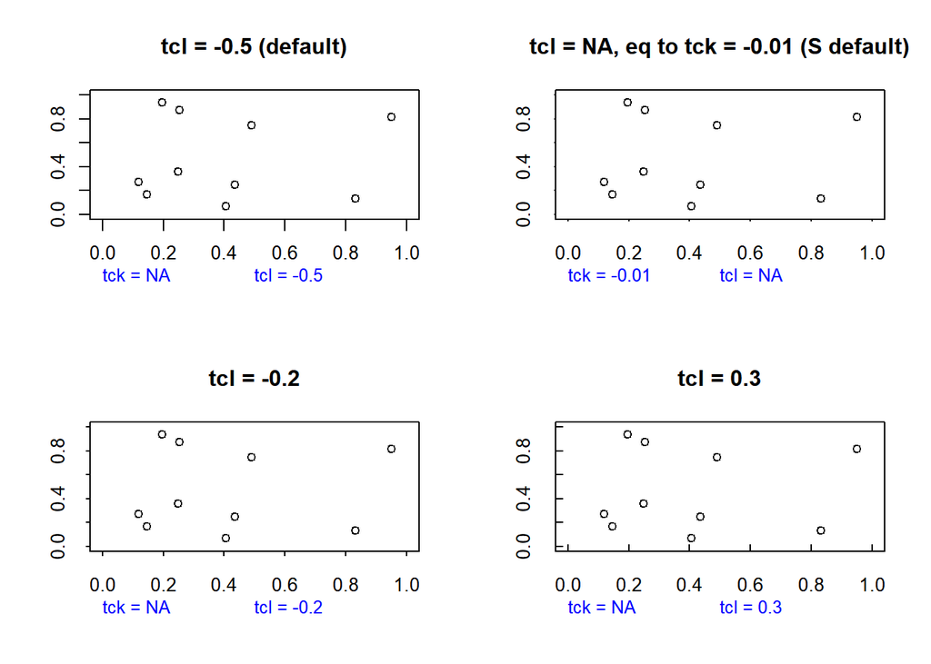

```r
opnew <- par(mfrow = c(2,2), tcl = -0.5)
set.seed(1023)
plot(runif(10), runif(10)
    ,xlim = c(0, 1), ylim = c(0, 1)
    ,xlab = "", ylab = ""
    ,main = "tcl = -0.5 (default)")
mtext(side = 1, line = 2, at = 0
    , paste0("tck = ", round(par("tck"), 2))
    , cex = 0.8, col = "blue", adj = 0)
mtext(side = 1, line = 2, at = 0.5
    , paste0("tcl = ", round(par("tcl"), 2))
    , cex = 0.8, col = "blue", adj = 0)

par(tcl = NA)
set.seed(1023)
plot(runif(10), runif(10)
    ,xlim = c(0, 1), ylim = c(0, 1)
    ,xlab = "", ylab = ""
    ,main = "tcl = NA, eq to tck = -0.01 (S default)")
mtext(side = 1, line = 2, at = 0
    , paste0("tck = ", round(par("tck"), 2))
    , cex = 0.8, col = "blue", adj = 0)
mtext(side = 1, line = 2, at = 0.5
    , paste0("tcl = ", round(par("tcl"), 2))
    , cex = 0.8, col = "blue", adj = 0)

par(tcl = -0.2)
set.seed(1023)
plot(runif(10), runif(10)
    ,xlim = c(0, 1), ylim = c(0, 1)
    ,xlab = "", ylab = ""
    ,main = "tcl = -0.2")
mtext(side = 1, line = 2, at = 0
    , paste0("tck = ", round(par("tck"), 2))
    , cex = 0.8, col = "blue", adj = 0)
mtext(side = 1, line = 2, at = 0.5
    , paste0("tcl = ", round(par("tcl"), 2))
    , cex = 0.8, col = "blue", adj = 0)

par(tcl = 0.3)
set.seed(1023)
plot(runif(10), runif(10)
    ,xlim = c(0, 1), ylim = c(0, 1)
    ,xlab = "", ylab = ""
    ,main = "tcl = 0.3")
mtext(side = 1, line = 2, at = 0
    , paste0("tck = ", round(par("tck"), 2))
    , cex = 0.8, col = "blue", adj = 0)
mtext(side = 1, line = 2, at = 0.5
    , paste0("tcl = ", round(par("tcl"), 2))
    , cex = 0.8, col = "blue", adj = 0)
```

```r
par(opnew)
```

## usr

A vector of the form c(x1, x2, y1, y2) giving the extremes of the user coordinates of the plotting region. When a logarithmic scale is in use (i.e., par(“xlog”) is true, see below), then the x-limits will be 10 ^ par(“usr”)[1:2]. Similarly for the y-axis.

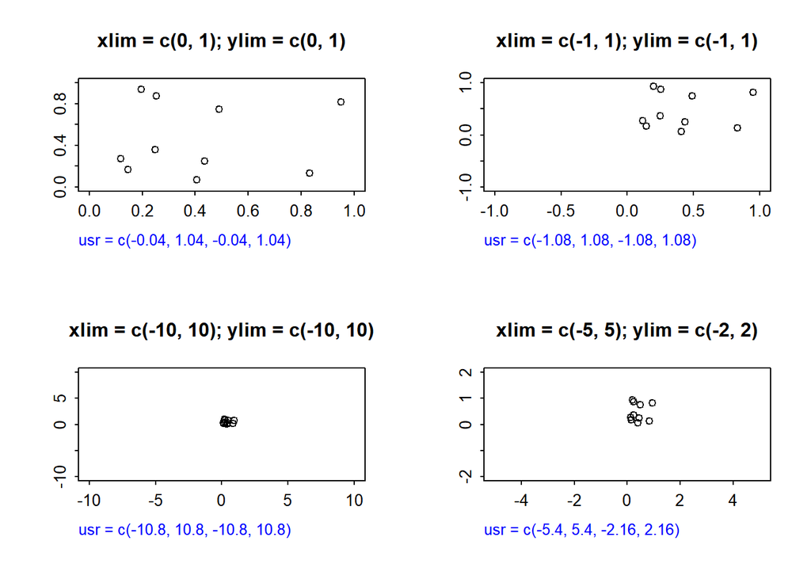

```r
opnew <- par(mfrow = c(2,2), tcl = -0.2, mgp = c(3, 0.5, 0))
set.seed(1023)
plot(runif(10), runif(10)
    , xlim = c(0, 1), ylim = c(0, 1)
    , xlab = "", ylab = ""
    , main = "xlim = c(0, 1); ylim = c(0, 1)")
mtext(side = 1, line = 2
    , paste0("usr = c(", paste(round(par("usr"), 2), collapse = ", "), ")")
    , cex = 0.8, col = "blue", adj = 0)

set.seed(1023)
plot(runif(10), runif(10)
    , xlim = c(-1, 1), ylim = c(-1, 1)
    , xlab = "", ylab = ""
    , main = "xlim = c(-1, 1); ylim = c(-1, 1)")
mtext(side = 1, line = 2
    , paste0("usr = c(", paste(round(par("usr"), 2), collapse = ", "), ")")
    , cex = 0.8, col = "blue", adj = 0)

set.seed(1023)
plot(runif(10), runif(10)
    , xlim = c(-10, 10), ylim = c(-10, 10)
    , xlab = "", ylab = ""
    , main = "xlim = c(-10, 10); ylim = c(-10, 10)")
mtext(side = 1, line = 2
    , paste0("usr = c(", paste(round(par("usr"), 2), collapse = ", "), ")")
    , cex = 0.8, col = "blue", adj = 0)

set.seed(1023)
plot(runif(10), runif(10)
    , xlim = c(-5, 5), ylim = c(-2, 2)
    , xlab = "", ylab = ""
    , main = "xlim = c(-5, 5); ylim = c(-2, 2)")
mtext(side = 1, line = 2
    , paste0("usr = c(", paste(round(par("usr"), 2), collapse = ", "), ")")
    , cex = 0.8, col = "blue", adj = 0)
```

```r
par(opnew)
```

## xaxp

A vector of the form c(x1, x2, n) giving the coordinates of the extreme tick marks and the number of intervals between tick-marks when par(“xlog”) is false. Otherwise, when log coordinates are active, the three values have a different meaning: For a small range, n is negative, and the ticks are as in the linear case, otherwise, n is in 1:3, specifying a case number, and x1 and x2 are the lowest and highest power of 10 inside the user coordinates, 10 ^ par(“usr”)[1:2]. (The “usr” coordinates are log10-transformed here!)

n = 1 will produce tick marks at 10^j for integer j,

n = 2 gives marks k 10^j with k in {1,5},

n = 3 gives marks k 10^j with k in {1,2,5}.

See axTicks() for a pure R implementation of this.

This parameter is reset when a user coordinate system is set up, for example by starting a new page or by calling plot.window or setting par(“usr”): n is taken from par(“lab”). It affects the default behaviour of subsequent calls to axis for sides 1 or 3.

It is only relevant to default numeric axis systems, and not for example to dates.

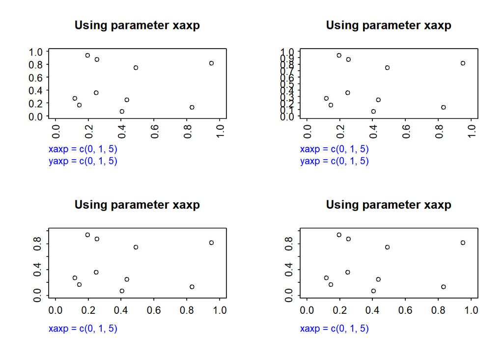

```r
opnew <- par(mfrow = c(2,2), tcl = -0.2, mgp = c(3, 0.5, 0))
set.seed(1023)
plot(runif(10), runif(10)
    ,xlim = c(0, 1), ylim = c(0, 1)
    ,xlab = "", ylab = ""
    ,main = "Using parameter xaxp"
    ,las = 2)
mtext(side = 1, line = 2
    , paste0("xaxp = c(", paste(round(par("xaxp"), 2), collapse = ", "), ")")
    , cex = 0.8, col = "blue", adj = 0)
mtext(side = 1, line = 3
    , paste0("yaxp = c(", paste(round(par("yaxp"), 2), collapse = ", "), ")")
    , cex = 0.8, col = "blue", adj = 0)

set.seed(1023)
par(xaxp = c(0, 1, 2))
plot(runif(10), runif(10)
    ,xlim = c(0, 1), ylim = c(0, 1)
    ,xlab = "", ylab = ""
    ,main = "Using parameter xaxp"
    ,las = 2
    ,yaxp = c(0, 1, 10)
    )
mtext(side = 1, line = 2
    , paste0("xaxp = c(", paste(round(par("xaxp"), 2), collapse = ", "), ")")
    , cex = 0.8, col = "blue", adj = 0)
mtext(side = 1, line = 3
    , paste0("yaxp = c(", paste(round(par("yaxp"), 2), collapse = ", "), ")")
    , cex = 0.8, col = "blue", adj = 0)

set.seed(1023)
plot(runif(10), runif(10)
    ,xlim = c(0, 1), ylim = c(0, 1)
    ,xlab = "", ylab = ""
    ,main = "Using parameter xaxp")
mtext(side = 1, line = 2
    , paste0("xaxp = c(", paste(round(par("xaxp"), 2), collapse = ", "), ")")
    , cex = 0.8, col = "blue", adj = 0)


set.seed(1023)
plot(runif(10), runif(10)
    ,xlim = c(0, 1), ylim = c(0, 1)
    ,xlab = "", ylab = ""
    ,main = "Using parameter xaxp")
mtext(side = 1, line = 2
    , paste0("xaxp = c(", paste(round(par("xaxp"), 2), collapse = ", "), ")")
    , cex = 0.8, col = "blue", adj = 0)
```

```r
par(opnew)
```

## xaxs

The style of axis interval calculation to be used for the x-axis. Possible values are “r”, “i”, “e”, “s”, “d”. The styles are generally controlled by the range of data or xlim, if given. Style “r” (regular) first extends the data range by 4 percent at each end and then finds an axis with pretty labels that fits within the extended range. Style “i” (internal) just finds an axis with pretty labels that fits within the original data range. Style “s” (standard) finds an axis with pretty labels within which the original data range fits. Style “e” (extended) is like style “s”, except that it is also ensures that there is room for plotting symbols within the bounding box. Style “d” (direct) specifies that the current axis should be used on subsequent plots. (Only “r” and “i” styles have been implemented in R.)

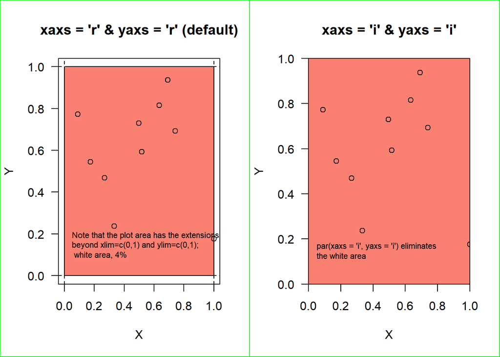

```r
par(mfrow = c(1, 2))

# Create a subwindow
# 1. plot area available when internal margins are 0
# par(mai = c(0, 0, 0, 0))

set.seed(1023)
plot(runif(10), runif(10), type = 'n', xlab = "X", ylab = "Y",
    xlim = c(0, 1), ylim = c(0, 1), las = 1)
rect(0,0,1,1, col = "salmon")
points(runif(10), runif(10))
title(main = "xaxs = 'r' & yaxs = 'r' (default)")

abline(h = c(0, 1), v = c(0, 1), lty = 2)
text(0.05, 0.15, "Note that the plot area has the extensions \nbeyond xlim=c(0,1) and ylim=c(0,1);\n white area, 4%", adj = 0, cex = 0.7)
box("figure", col = "green")

# 2. Parameter to delete extra space
par(xaxs = 'i', yaxs = 'i')

set.seed(1023)
plot(runif(10), runif(10), type = 'n',
    xlab = 'X', ylab = 'Y', xlim = c(0, 1), ylim = c(0, 1), las = 1)
rect(0,0,1,1, col = "salmon")
points(runif(10), runif(10))
title(main = "xaxs = 'i' & yaxs = 'i'")

text(0.05, 0.15, "par(xaxs = 'i', yaxs = 'i') eliminates\nthe white area", adj = 0, cex = 0.7)
box("figure", col = "green")
```

## xaxt

A character which specifies the x axis type. Specifying “n” suppresses plotting of the axis. The standard value is “s”: for compatibility with S values “l” and “t” are accepted but are equivalent to “s”: any value other than “n” implies plotting.

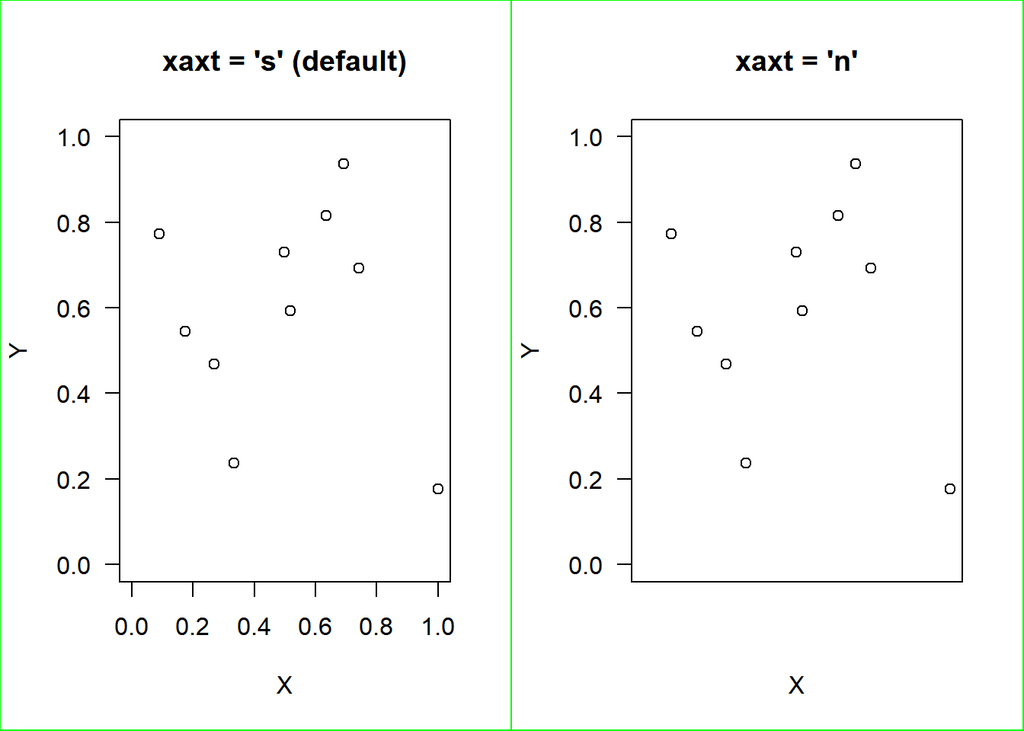

```r
par(mfrow = c(1, 2))

set.seed(1023)
plot(runif(10), runif(10), type = 'n', xlab = "X", ylab = "Y",
    xaxt = 's', xlim = c(0, 1), ylim = c(0, 1), las = 1)

points(runif(10), runif(10))
title(main = "xaxt = 's' (default)")
box("figure", col = "green")


set.seed(1023)
plot(runif(10), runif(10), type = 'n',
    xaxt = 'n', xlab = 'X', ylab = 'Y', xlim = c(0, 1), ylim = c(0, 1), las = 1)
points(runif(10), runif(10))
title(main = "xaxt = 'n'")
box("figure", col = "green")
```

## xlog

A logical value (see log in plot.default). If TRUE, a logarithmic scale is in use (e.g., after plot(*, log = “x”)). For a new device, it defaults to FALSE, i.e., linear scale.

## xpd

A logical value or NA. If FALSE, all plotting is clipped to the plot region, if TRUE, all plotting is clipped to the figure region, and if NA, all plotting is clipped to the device region. See also clip.

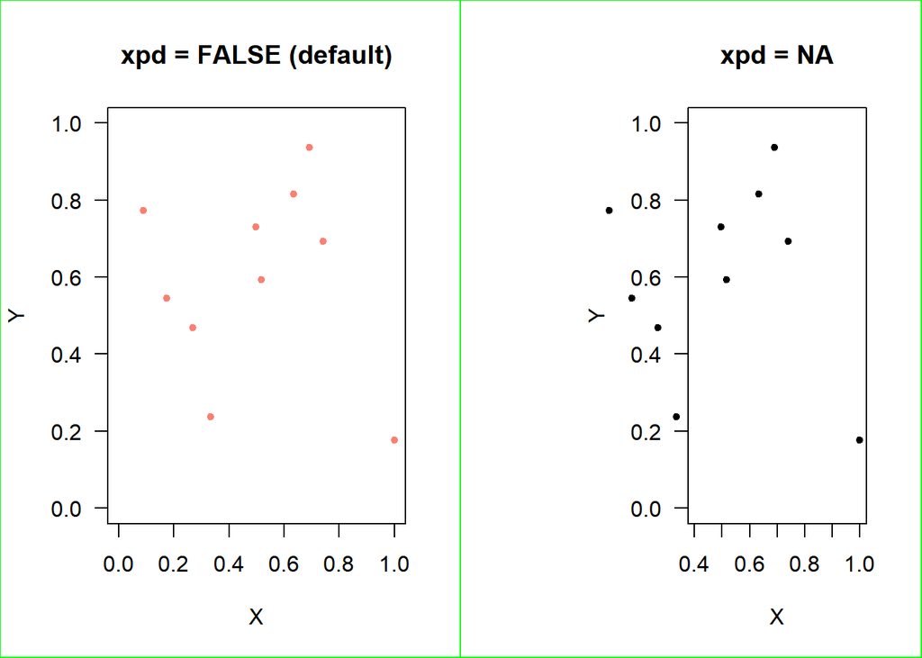

```r
par(mfrow = c(1, 2))

set.seed(1023)
plot(runif(10), runif(10), type = 'n', xlab = "X", ylab = "Y",
    xlim = c(0, 1), ylim = c(0, 1), las = 1)
points(runif(10), runif(10), pch = 20, col = "salmon")
title(main = "xpd = FALSE (default)")
box("figure", col = "green")

plot_plt <- par("plt")
par(xpd = NA, plt = c(0.6 * plot_plt[1] + 0.4 * plot_plt[2], plot_plt[2:4]))
set.seed(1023)
plot(runif(10) , runif(10), type = 'n',
    xlab = 'X', ylab = 'Y', xlim = c(0.4, 1), ylim = c(0, 1), las = 1)
points(runif(10), runif(10), pch = 20)
title(main = "xpd = NA")
box("figure", col = "green")
```

## yaxp

A vector of the form c(y1, y2, n) giving the coordinates of the extreme tick marks and the number of intervals between tick-marks unless for log coordinates, see xaxp above.

## yaxs

The style of axis interval calculation to be used for the y-axis. See xaxs above.

## yaxt

A character which specifies the y axis type. Specifying “n” suppresses plotting.

## ylbias

A positive real value used in the positioning of text in the margins by axis and mtext. The default is in principle device-specific, but currently 0.2 for all of R’s own devices. Set this to 0.2 for compatibility with R < 2.14.0 on x11 and windows() devices.

## ylog

A logical value; see xlog above.

# Additonal examples

## Personalized grid

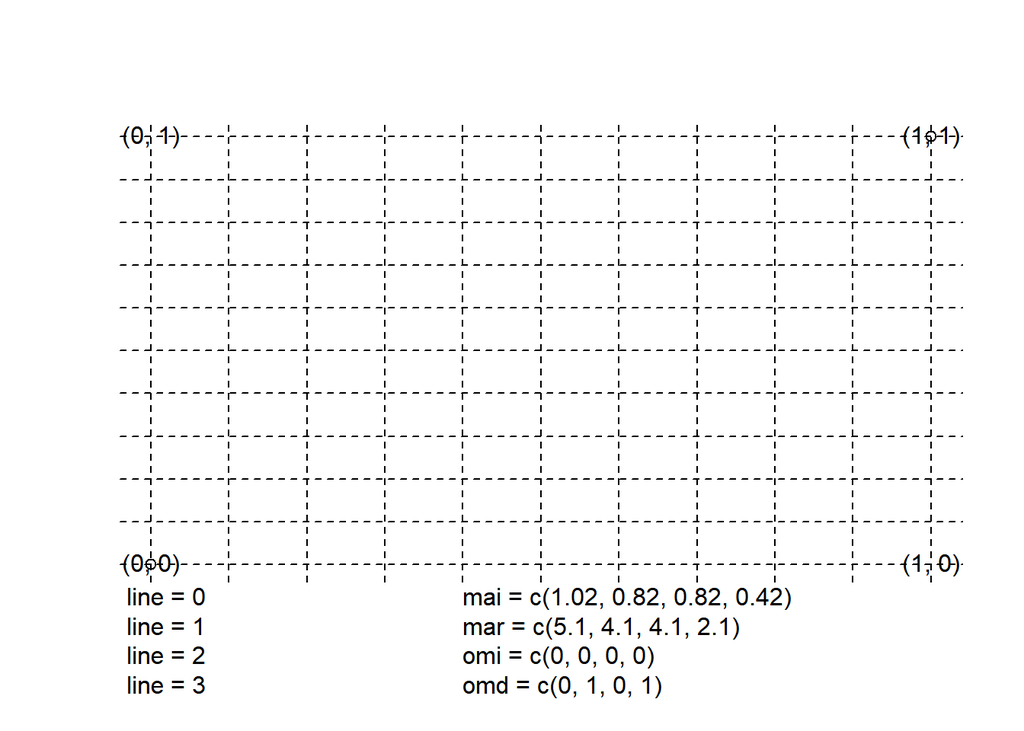

```r
plot(0:1, 0:1, axes = FALSE, xlab = "", ylab = "")

text(0, 0, "(0, 0)")
text(1, 0, "(1, 0)")
text(0, 1, "(0, 1)")
text(1, 1, "(1, 1)")

mtext(paste0("mai = c(", paste(op$mai, collapse = ", "), ")"), line = 0
    , side = 1, at = 0.4, adj = 0)
mtext(paste0("mar = c(", paste(op$mar, collapse = ", "), ")"), line = 1
    , side = 1, at = 0.4, adj = 0)
mtext(paste0("omi = c(", paste(op$omi, collapse = ", "), ")"), line = 2
    , side = 1, at = 0.4, adj = 0)
mtext(paste0("omd = c(", paste(op$omd, collapse = ", "), ")"), line = 3
    , side = 1, at = 0.4, adj = 0)

mtext(paste0(" line = 0"), line = 0, side = 1, adj = 0)
mtext(paste0(" line = 1"), line = 1, side = 1, adj = 0)
mtext(paste0(" line = 2"), line = 2, side = 1, adj = 0)
mtext(paste0(" line = 3"), line = 3, side = 1, adj = 0)

abline(v = c(seq(0, 1, 0.1)), h = c(seq(0, 1, 0.1)), lty = 2)
```

## Inside plot

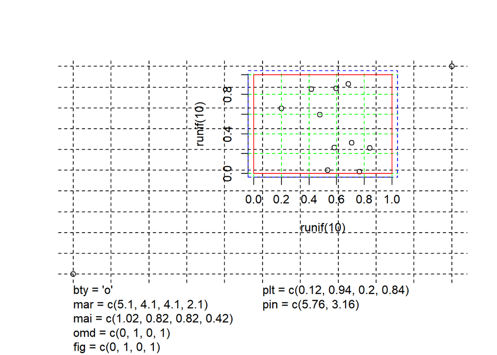

```r
par(op)
plot(0:1, 0:1, axes = FALSE, bty = 'o', xlab = "", ylab = "")
mtext(paste0("bty = ", "'o'")
    , line = 0, side = 1, adj = 0, at = 0)
mtext(paste0("mar = c(", paste(op$mar, collapse = ", "), ")")
    , line = 1, side = 1, adj = 0, at = 0)
mtext(paste0("mai = c(", paste(op$mai, collapse = ", "), ")")
    , line = 2, side = 1, adj = 0, at = 0)
mtext(paste0("omd = c(", paste(round(op$omd, 2), collapse = ", "), ")")
    , line = 3, side = 1, adj = 0, at = 0)
mtext(paste0("fig = c(", paste(op$fig, collapse = ", "), ")")
    , line = 4, side = 1, adj = 0, at = 0)
mtext(paste0("plt = c(", paste(round(op$plt, 2), collapse = ", "), ")")
    , line = 0, side = 1, adj = 0, at = 0.5)
mtext(paste0("pin = c(", paste(round(op$pin, 2), collapse = ", "), ")")
    , line = 1, side = 1, adj = 0, at = 0.5)

abline(v = c(seq(0, 1, 0.1)), h = c(seq(0, 1, 0.1)), lty = 2)

# Inside plot
par(plt = c(0.5, 0.8, 0.5, 0.8), new = TRUE)
plot(runif(10), runif(10), xlim = c(0, 1), ylim = c(0, 1), bty = 'n')
rect(0, 0, 1, 1, border = "red", lty = 1)
box(which = "plot", lty = 2, col = 'blue' )
grid(lty = 2, col = "green")
rect(0, 0, 1, 1, border = "red", lty = 1)
```

## Initial grid with NDC

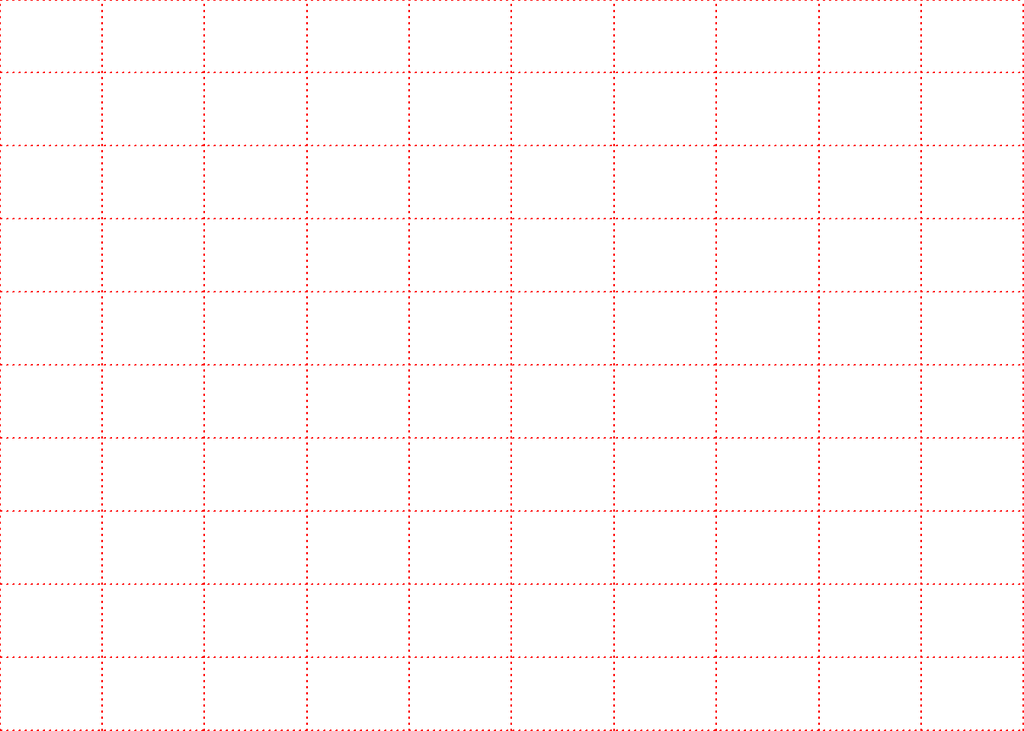

```r
# clean plot area to start drawing
opnew <- par(mar = rep(0, 4))
plot(1, 1
    , type = 'n', axes = FALSE, ann = FALSE
    , xaxs = 'i', yaxs = 'i'
    , xlim = c(0,10), ylim = c(0,10)
    , lab = c(10, 10, 7))
grid(col = "red")
```

```r
par(opnew)
```

## Backgroung default Plot

You can use this plot to compare it with changes in the graphics parameters with and overlayed plot. Remember to use `par(new = TRUE)`

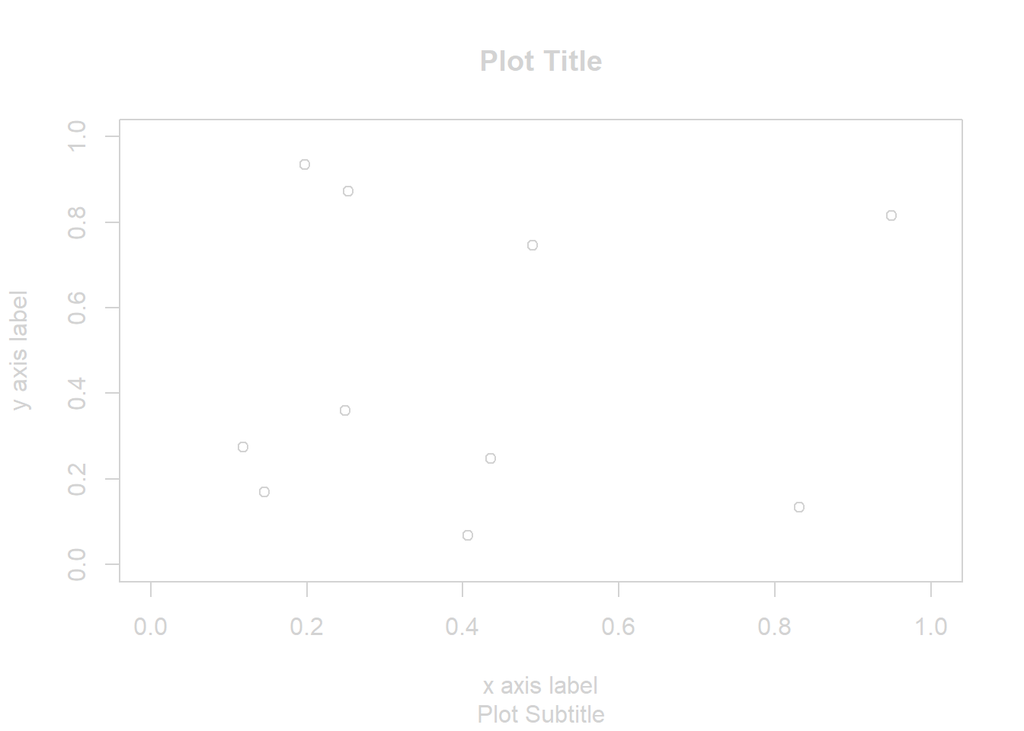

```r
par(op)

# start by plotting a normal plot with standard parameter but in light colors
plot_color <- "lightgray"
par( col.main = plot_color
    , col.lab = plot_color
    , col.sub = plot_color
    , col.axis = plot_color
    , fg = plot_color)
set.seed(1023)
plot(runif(10), runif(10)
    , type = 'p', xlim = c(0, 1), ylim = c(0, 1),
    xlab = "x axis label", ylab = "y axis label"
    , main = "Plot Title"
    , sub = "Plot Subtitle")
```

```r
par(op)
```

## Change number of ticks in axis

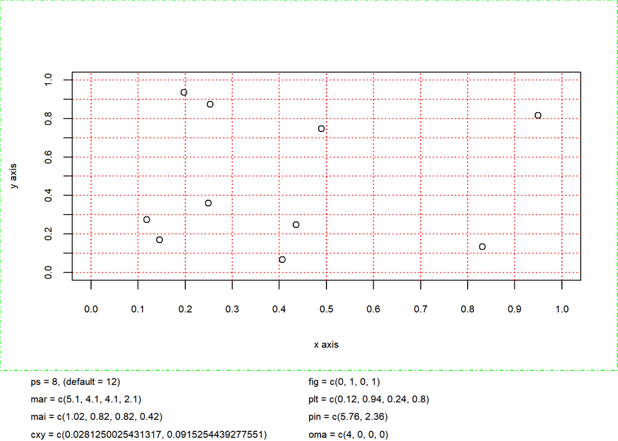

```r
text_info <- function(){
    mtext(paste0("ps = ", "8, (default = 12)")
        , line = 0, side = 1, at = 0.05, adj = 0, outer = TRUE)
    mtext(paste0("mar = c(", paste(par("mar"), collapse = ", "), ")")
        , line = 1, side = 1, at = 0.05, adj = 0, outer = TRUE)
    mtext(paste0("mai = c(", paste(par("mai"), collapse = ", "), ")")
        , line = 2, side = 1, at = 0.05, adj = 0, outer = TRUE)
    mtext(paste0("cxy = c(", paste(par("cxy"), collapse = ", "), ")")
        , line = 3, side = 1, at = 0.05, adj = 0, outer = TRUE)
    mtext(paste0("fig = c(", paste(par("fig"), collapse = ", "), ")")
        , line = 0, side = 1, at = 0.5, adj = 0, outer = TRUE)
    mtext(paste0("plt = c(", paste(round(par("plt"), 2), collapse = ", "), ")")
        , line = 1, side = 1, at = 0.5, adj = 0, outer = TRUE)
    mtext(paste0("pin = c(", paste(round(par("pin"), 2), collapse = ", "), ")")
        , line = 2, side = 1, at = 0.5, adj = 0, outer = TRUE)
    mtext(paste0("oma = c(", paste(round(par("oma"), 2), collapse = ", "), ")")
        , line = 3, side = 1, at = 0.5, adj = 0, outer = TRUE)
}

par(ps = 8, oma = c(4, 0, 0, 0))

set.seed(1023)
plot(runif(10), runif(10)
    , xlim = c(0, 1), ylim = c(0, 1)
    , xlab = "x axis", ylab = "y axis"
    , lab = c(10, 10, 7))
box("inner", lty = 4, col = "green")
grid(col = "red")
text_info()
```

## Plot dimensions and inner figure

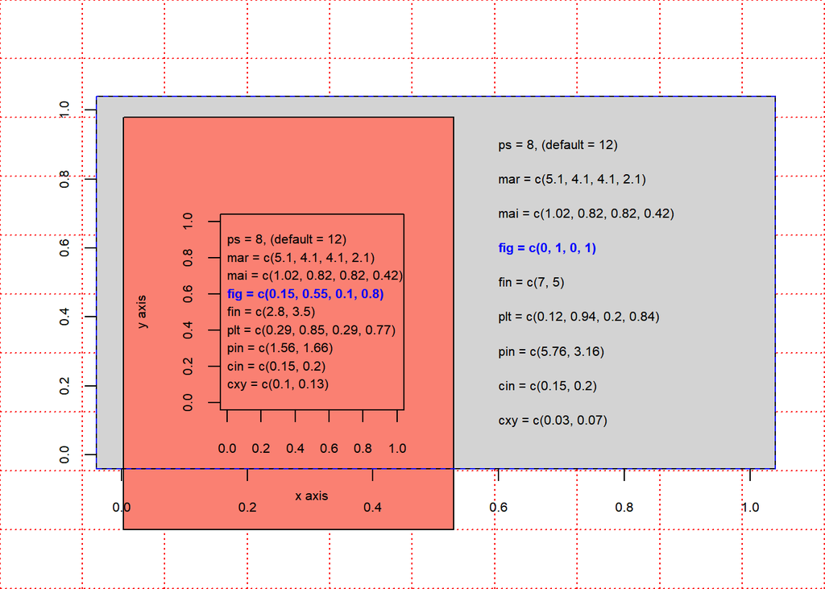

```r
text_info <- function(x){
    text(x, 0.9, paste0("ps = ", "8, (default = 12)"), adj = 0)
    text(x, 0.8, paste0("mar = c(", paste(par("mar"), collapse = ", "), ")"), adj = 0)
    text(x, 0.7, paste0("mai = c(", paste(par("mai"), collapse = ", "), ")"), adj = 0)
    text(x, 0.6, paste0("fig = c(", paste(round(par("fig"), 2), collapse = ", "), ")")
        , adj = 0, font = 2, col = "blue")
    text(x, 0.5, paste0("fin = c(", paste(round(par("fin"), 2), collapse = ", "), ")")
        , adj = 0)
    text(x, 0.4, paste0("plt = c(", paste(round(par("plt"), 2), collapse = ", "), ")")
        , adj = 0)
    text(x, 0.3, paste0("pin = c(", paste(round(par("pin"), 2), collapse = ", "), ")")
        , adj = 0)
    text(x, 0.2, paste0("cin = c(", paste(round(par("cin"), 2), collapse = ", "), ")")
        , adj = 0)
    text(x, 0.1, paste0("cxy = c(", paste(round(par("cxy"), 2), collapse = ", "), ")")
        , adj = 0)
}
par(op)

oldpar <- par(mar = rep(0, 4))
plot(1, 1
    , type = 'n', axes = FALSE, ann = FALSE
    , xaxs = 'i', yaxs = 'i'
    , xlim = c(0,10), ylim = c(0,10)
    , lab = c(10, 10, 7))
grid(col = "red")

# Rectangle with Default plot dimensions
plt <- op$plt
rect(plt[1] * 10, plt[3] * 10, plt[2] * 10, plt[4] * 10, col = "lightgray")

# Rectangle with dimensions of inner figure
rect(1.5, 1, 5.5, 8, col = "salmon")
par(oldpar)

oldpar_2 <- par(ps = 8, new = TRUE)
plot(0:1, 0:1, typ = 'n', axes = TRUE, xlab = "", ylab = "")
text_info(0.6)
box("plot", lty = 2, col = "blue")
par(oldpar_2)

oldpar_3 <- par(fig = c(0.15, 0.55, 0.1, 0.8), ps = 8, new = TRUE)
set.seed(1023)
plot(runif(10), runif(10), type = 'n'
    , xlim = c(0, 1), ylim = c(0, 1)
    , xlab = "x axis", ylab = "y axis")
text_info(0)
```

```r
par(oldpar_3)
```

## Change figure dimensions

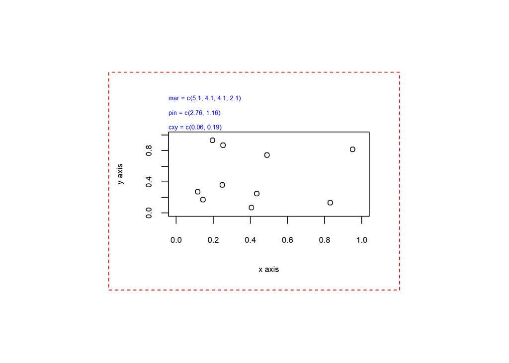

```r
#oldpar_3 <- par(fig = c(0.1, 0.9, 0.1, 0.9), ps = 8)
oldpar_3 <- par(fin = c(4, 3), ps = 8)
set.seed(1023)
plot(runif(10), runif(10)
    , xlim = c(0, 1), ylim = c(0, 1)
    , xlab = "x axis", ylab = "y axis"
    )
mtext(side = 3, line = 0
    , paste0("cxy = c(", paste(round(par("cxy"), 2), collapse = ", "), ")")
    , cex = 0.8, col = "blue", adj = 0)
mtext(side = 3, line = 1
    , paste0("pin = c(", paste(round(par("pin"), 2), collapse = ", "), ")")
    , cex = 0.8, col = "blue", adj = 0)
mtext(side = 3, line = 2
    , paste0("mar = c(", paste(round(par("mar"), 2), collapse = ", "), ")")
    , cex = 0.8, col = "blue", adj = 0)
box("figure", lty = 2, col = "red")
```

```r
par(oldpar_3)
```

## Margins highlighted

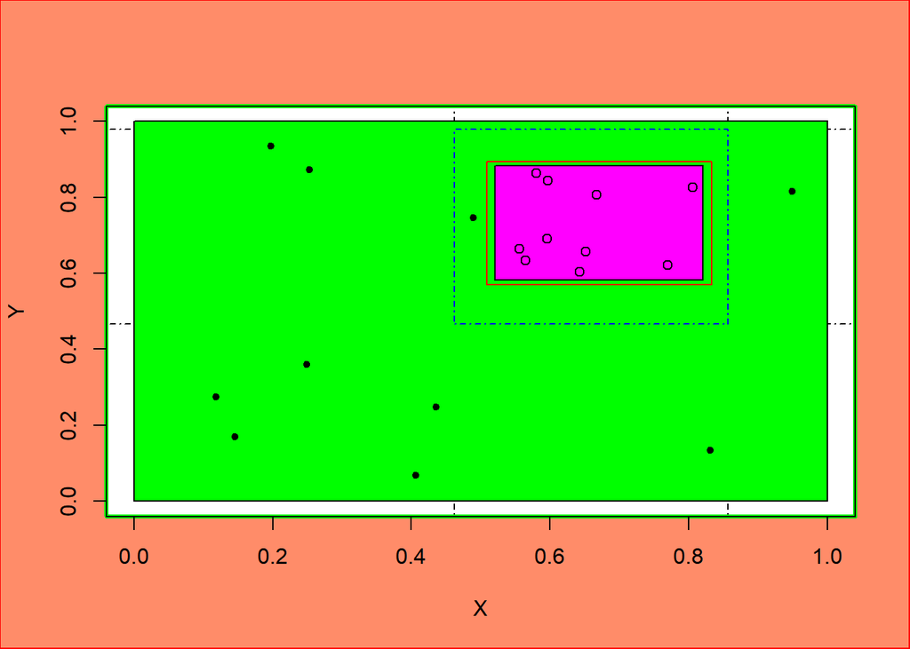

```r
par(op)

# Create a subwindow
# 1. plot area available when internal margins are 0

oldpar <- par(mai = c(0, 0, 0, 0), xaxs = 'i', yaxs = 'i')
plot.new()

# set the fig margins
abline(h = c(0.5, 0.8), v = c(0.5, 0.8), lty = 4)
box("figure", lty = 1, col = "red")

# color margins
prop <- oldpar$mai/rep(rev(par("fin")), 2)
rect(0,0,1,prop[1], col = "salmon1", border = NA)
rect(0,0,prop[2], 1, col = "salmon1", border = NA)
rect(0,1 - prop[3],1, 1, col = "salmon1", border = NA)
rect(1 - prop[4], 0 , 1, 1, col = "salmon1", border = NA)
par(oldpar)

# show plot area
box("plot", lty = 1, lwd = 3, col = "green")

# plot a plot
set.seed(1023)
par(new = TRUE)
plot(runif(10), runif(10), typ = 'n',
    xlab = 'X', ylab = 'Y', xlim = c(0, 1), ylim = c(0, 1))

# Concrete area to plot
rect(0,0,1,1, col = "green")

set.seed(1023)
points(runif(10), runif(10), pch = 20)
box("figure", lty = 1, col = "red")


# 2. Parameter to delete extra space

newfig <- c(0.5, 0.8, 0.5, 0.8)
newscale <- c(newfig[2] - newfig[1], newfig[4] - newfig[3])
par(fig = newfig, new = TRUE)
oldpar <- par(mai = par("mai") * rep(rev(newscale), 2))
rect(0, 0, 1, 1, col = "magenta")
set.seed(1023)
par(new = TRUE)
plot(runif(10), runif(10), xlim = c(0, 1), ylim = c(0, 1), axes = FALSE)
box("plot", lty = 1, col = "red")
box("figure", lty = 4, col = "blue")
```

## Plot area extension controled by xaxs and yaxs

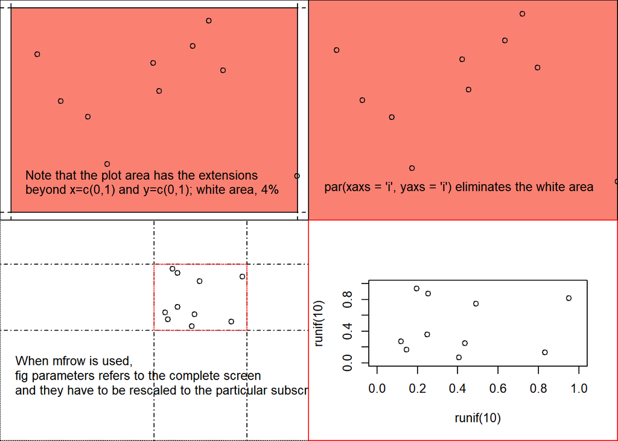

```r
par(mfrow = c(2, 2))

# Create a subwindow
# 1. plot area available when internal margins are 0
par(mai = c(0, 0, 0, 0))

set.seed(1023)
plot(runif(10), runif(10), type = 'n',
    yaxt = 'n', xaxt = 'n', xlab = '', ylab = '', xlim = c(0, 1), ylim = c(0, 1))
rect(0,0,1,1, col = "salmon")
points(runif(10), runif(10))

abline(h = c(0, 1), v = c(0, 1), lty = 2)
text(0.05, 0.15, "Note that the plot area has the extensions \nbeyond x=c(0,1) and y=c(0,1); white area, 4%", adj = 0)
box("plot", lty = "11")

# 2. Parameter to delete extra space
par(xaxs = 'i', yaxs = 'i')

set.seed(1023)
plot(runif(10), runif(10), type = 'n',
    yaxt = 'n', xaxt = 'n', xlab = '', ylab = '', xlim = c(0, 1), ylim = c(0, 1))
rect(0,0,1,1, col = "salmon")
points(runif(10), runif(10))

abline(h = c(0, 1), v = c(0, 1), lty = 2)
text(0.05, 0.15, "par(xaxs = 'i', yaxs = 'i') eliminates the white area", adj = 0)
box("plot", lty = "11")

# 3. We create a subplot in an area

plot.new()
box("plot", lty = "11")
abline(h = c(0.5, 0.8), v = c(0.5, 0.8), lty = 4)
text(0.05, 0.3,
    "When mfrow is used,
fig parameters refers to the complete screen
and they have to be rescaled to the particular subscreen", adj = 0)


par(fig = c(0.25, 0.4, 0.25, 0.4), new = TRUE)
set.seed(1023)
plot(runif(10), runif(10), xlim = c(0, 1), ylim = c(0, 1), axes = FALSE)
box("plot", lty = "11", col = "red")

# 4. rescale mai parameter to fully plot the complete plot in the subregion
par(fig = c(0.5, 1, 0, 0.5), xaxs = op$xaxs, yaxs = op$xaxs, new = TRUE)
# 0.83 is the factor to rescale margin as the figure area is split in 4 figures
par(mai = 0.83 * op$mai)
set.seed(1023)
plot(runif(10), runif(10), xlim = c(0, 1), ylim = c(0, 1))
box("figure", lty = 1, col = "red")
```

## Plot signature

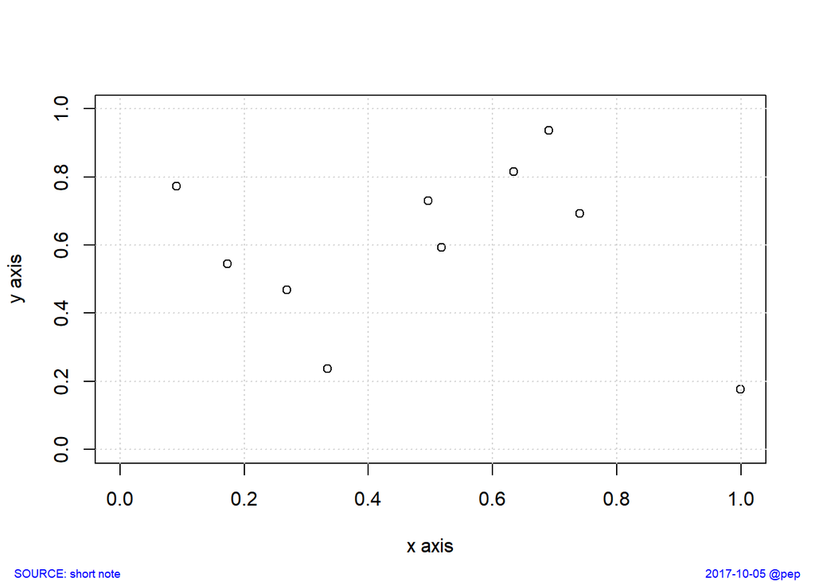

```r
outer_margin <- function(left_note = "", right_note = "", ...) {
    oldpar <- par(oma = c(1, 0, 0, 0))
    # box("inner", col = "green")

    mtext(left_note, line = 0, adj = 0.02, side = 1, outer = TRUE, ...)
    mtext(right_note, line = 0, adj = 0.98, side = 1, outer = TRUE, ...)
    par(oldpar)
}

par(op)
plot(runif(10), runif(10)
    , xlim = c(0, 1), ylim = c(0, 1)
    , xlab = "x axis", ylab = "y axis"
    )
grid()
outer_margin("SOURCE: short note", "2017-10-05 @pep", cex = 0.6, col = "blue")
```